# week_06_seaborn_bar_charts

## CMPINF 2100 Week 06

### Seaborn Bar Charts

We will again use matplotlib to organize the layout of the figure. But this time, the bar charts will be created with the Seaborn stat plotting module. This module displays the graphics differently than Pandas. But Seaborn really likes to work with Pandas DataFrames!!

We therefore need ALL modules that we have worked with this semester!!

## Import Modules

```python
import numpy as np
import pandas as pd
import matplotlib.pyplot as plt

import seaborn as sns
```

```python
%whos
```

```
Variable   Type      Data/Info
------------------------------
np         module    <module 'numpy' from '/Ap<...>kages/numpy/__init__.py'>
pd         module    <module 'pandas' from '/A<...>ages/pandas/__init__.py'>
plt        module    <module 'matplotlib.pyplo<...>es/matplotlib/pyplot.py'>
sns        module    <module 'seaborn' from '/<...>ges/seaborn/__init__.py'>
```

## Read data

We will use the gap minder data set again.

```python
gap_df = pd.read_csv("gapminder.tsv", sep="\t")
```

```python
gap_df.info()
```

```
<class 'pandas.core.frame.DataFrame'>
RangeIndex: 1704 entries, 0 to 1703
Data columns (total 6 columns):
 #   Column     Non-Null Count  Dtype
---  ------     --------------  -----
 0   country    1704 non-null   object
 1   continent  1704 non-null   object
 2   year       1704 non-null   int64
 3   lifeExp    1704 non-null   float64
 4   pop        1704 non-null   int64
 5   gdpPercap  1704 non-null   float64
dtypes: float64(2), int64(2), object(2)
memory usage: 80.0+ KB
```

```python
penguins = sns.load_dataset("penguins")
```

```python
penguins.info()
```

```
<class 'pandas.core.frame.DataFrame'>
RangeIndex: 344 entries, 0 to 343
Data columns (total 7 columns):
 #   Column             Non-Null Count  Dtype
---  ------             --------------  -----
 0   species            344 non-null    object
 1   island             344 non-null    object
 2   bill_length_mm     342 non-null    float64
 3   bill_depth_mm      342 non-null    float64
 4   flipper_length_mm  342 non-null    float64
 5   body_mass_g        342 non-null    float64
 6   sex                333 non-null    object
dtypes: float64(4), object(3)
memory usage: 18.9+ KB
```

The previous recording showed how to make bar charts with Pandas started with the gapminder data. But lets being with Penguines in this example.

### Counts for Penguins

```python
penguins.dtypes
```

```
species               object
island                object
bill_length_mm       float64
bill_depth_mm        float64
flipper_length_mm    float64
body_mass_g          float64
sex                   object
dtype: object
```

```python
penguins.nunique()
```

```
species                3
island                 3
bill_length_mm       164
bill_depth_mm         80
flipper_length_mm     55
body_mass_g           94
sex                    2
dtype: int64
```

Seaborn works diff than plotting in Pandas.

Seaborn divides functions into two main categories:

- FIGURE level functions
- AXES level functions

Axes-level functions create SPECIFIC kinds of plots.

Figure level functions are "GOAL ORIENTED".

Let's begin with the Axes level so we can practice using specific KINDS of plots.

I like visualize BAR CHARTs in Seaborn using the sns.countplot() function. We are therefore COUNTING the values and PLOTTING.

Seaborn AXES level functions are built on top of matplotlib and so we need to define the FIGURE and AXES objects.

As a reminder, when we worked with Pandas...

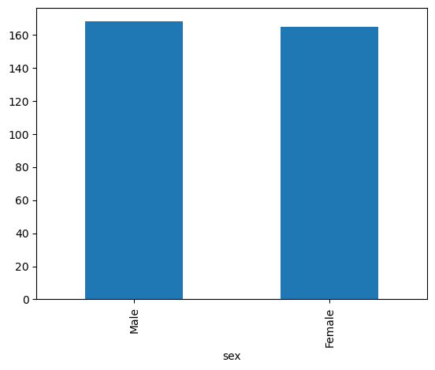

```python
fig, ax = plt.subplots()

penguins.sex.value_counts().plot(kind="bar", ax=ax)

plt.show()
```

Seaborn follows a similar process but there is ONE MAJOR difference

When plotting with Pandas we must SPECIFY that we are counting. But when using Seaborn, Seaborn does the counting for us!!!

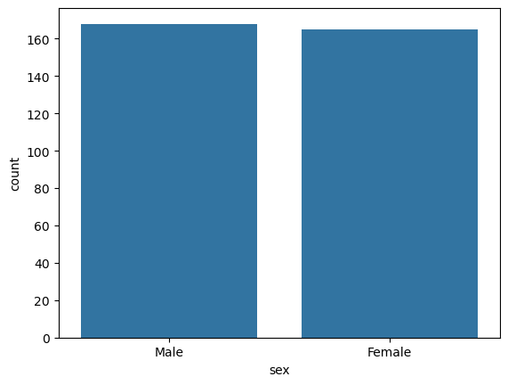

```python
fig, ax = plt.subplots()

sns.countplot(data=penguins, x = "sex", ax=ax)

plt.show()
```

```python
penguins.sex.value_counts(dropna=False)
```

```
sex
Male      168
Female    165
NaN        11
Name: count, dtype: int64
```

If we want to show a horizontal bar chart in Seaborn we must assign the variable to the y argument.

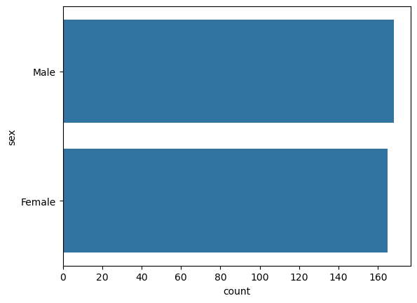

```python
fig, ax = plt.subplots()

sns.countplot(data=penguins, y="sex", ax=ax)

plt.show()
```

But we can create the same figure using the FIGURE LEVEL function instead!!

We are working with the cat vars and so the figure level function is sns.catplot()

The catplot() figure level function requires we specify the kind of plot!!

We do NOT need to define the figure and axis OBJECTS when working with FIGURE LEVEL FUNCTIONS in Seaborn!!!

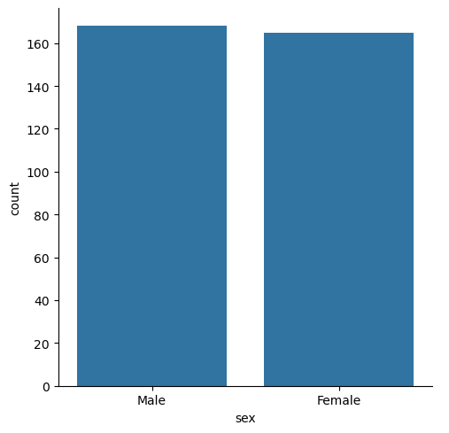

```python
sns.catplot(data=penguins, x="sex", kind="count")

plt.show()
```

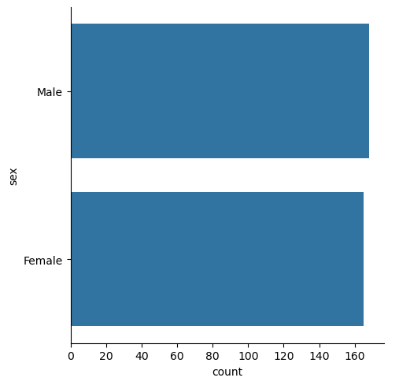

```python
sns.catplot(data=penguins, y="sex", kind="count")

plt.show()
```

Changing the figure size requires the height and aspect arguments.

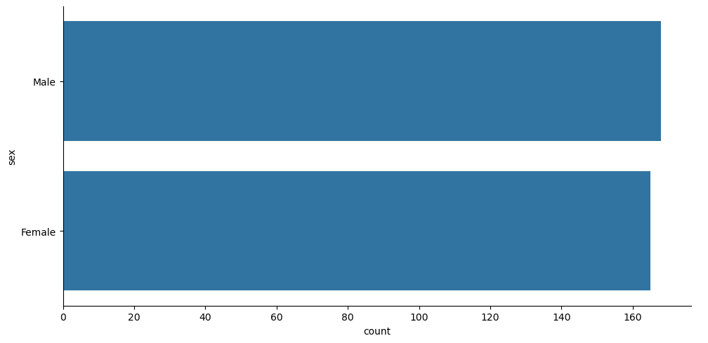

```python
sns.catplot(data=penguins, y="sex", kind="count", aspect=2)

plt.show()
```

Look at bar charts for the other vars in Penguins.

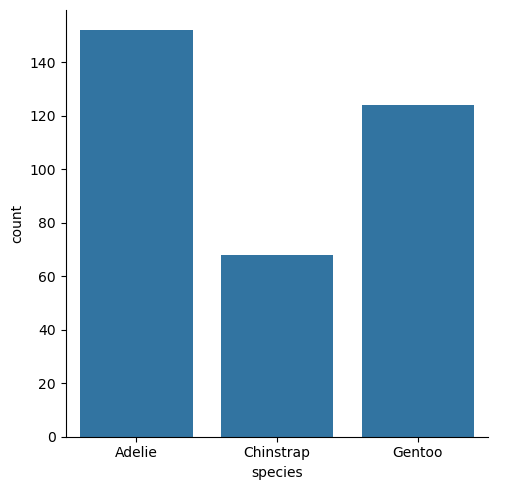

```python
sns.catplot(data=penguins, x="species", kind="count")

plt.show()
```

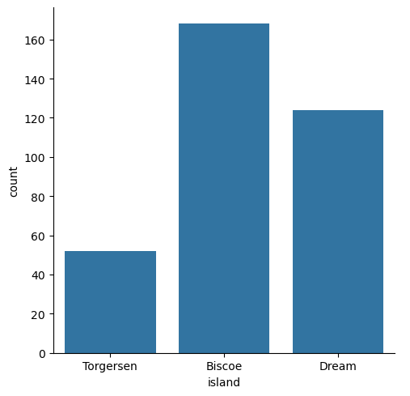

```python
sns.catplot(data=penguins, x="island", kind="count")

plt.show()
```

## Gapminder counts

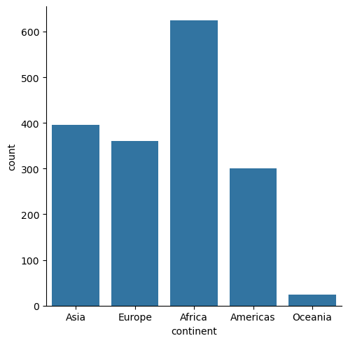

```python
sns.catplot(data=gap_df, x="continent", kind="count")

plt.show()
```

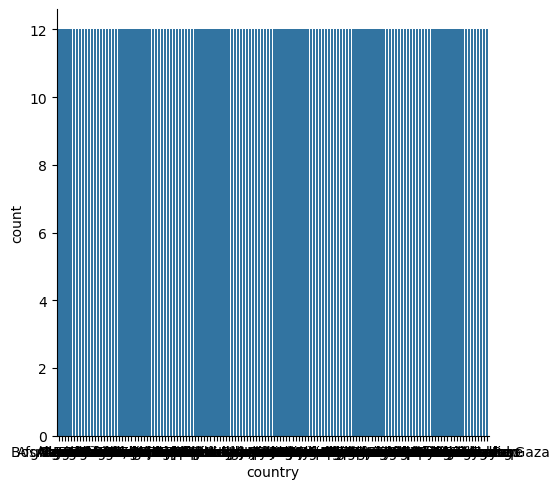

```python
sns.catplot(data=gap_df, x="country", kind="count")

plt.show()
```

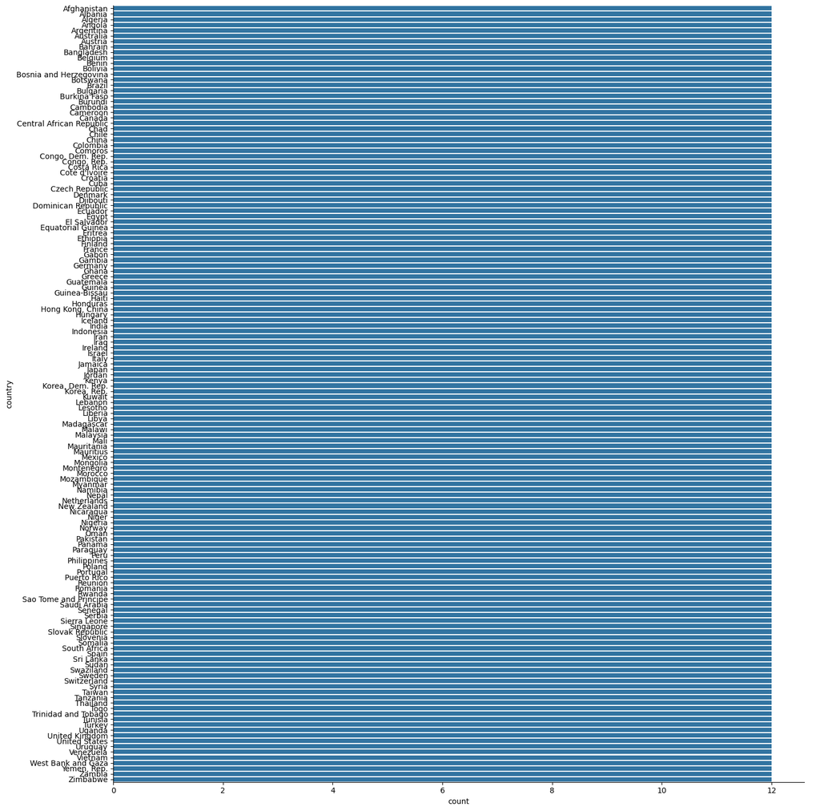

```python
sns.catplot(data=gap_df, y="country", kind="count", height=15)

plt.show()
```

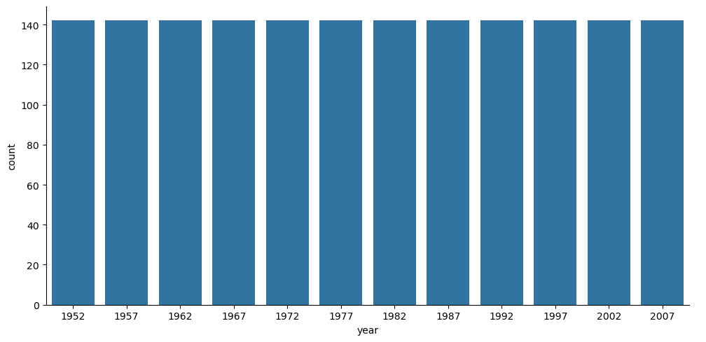

```python
sns.catplot(data=gap_df, x="year", kind="count", aspect=2)

plt.show()
```